# Supervised segmentation and Decision Trees

**Задача:** разработать такие правила, которые позволят разделить данные на группы в соответствии с каком-то интересующим нас показателем.

Примеры:

- есть растения нескольких сортов, нужно выделить признаки, характеризующие каждый сорт
- есть ряд диагнозов, необходимо определить симптомы, соответствующие диагнозу
- есть база клиентов с указанием, кто продолжает пользоваться сервисоами компании, а кто ушел. Нужно выделить признаки, которые позволят выявить “проблемных” клиентов
- …
- Зачем это нужно? Приведите ваши примеры подобных задач.
- Нужно ли использовать все имеющиеся у нас переменные?
- Как определить, какие из них важны?

Подобные задачи делятся на две групы: задачи регрессии и задачи классификации. Задача классификации возникает в том случае, если интересующим нас показателем является принадлежность в некоторому классу (болен/не болен, спам/не спам, ушел/остался, высокий/средний/низкий…) – т.е. категориальная переменная.

Про задачу регрессии мы говорим тогда, когда мы хотим предсказать некий количественный, числовой показатель (уровень продаж, рейтинг, риск заразиться…).

Рассмотрим, как подобные задачи можно решать с помощью R. Будем использовать пакет `partykit`.

```r
library(partykit)
```

### Построение классификационных деревьев

Работаем сегодня с данными Carseats из пакета ISLR о продаже детских автомобильных кресел.

```r
library(ISLR)
?ISLR::Carseats
```

- К какому типу переменных относится Sales?

Т.к. классификационные деревья предсказывают принадлежность к той или иной категории, то изменим немного наши данные

```r
carseats <- ISLR::Carseats
High=ifelse(carseats$Sales<=8,"No","Yes")
library(dplyr)
Carseats <- data.frame(carseats, High)
Carseats <- dplyr::select(Carseats, -Sales)
```

Построим дерево

```r
tree.carseats <- ctree(High~., data = Carseats)
tree.carseats
```

```
##
## Model formula:
## High ~ CompPrice + Income + Advertising + Population + Price +
##     ShelveLoc + Age + Education + Urban + US
##
## Fitted party:
## [1] root
## |   [2] ShelveLoc in Bad, Medium
## |   |   [3] Price <= 92: Yes (n = 46, err = 30.4%)
## |   |   [4] Price > 92
## |   |   |   [5] Advertising <= 13
## |   |   |   |   [6] CompPrice <= 124: No (n = 96, err = 6.2%)
## |   |   |   |   [7] CompPrice > 124
## |   |   |   |   |   [8] Price <= 109: Yes (n = 21, err = 28.6%)
## |   |   |   |   |   [9] Price > 109: No (n = 107, err = 18.7%)
## |   |   |   [10] Advertising > 13
## |   |   |   |   [11] Age <= 54: Yes (n = 25, err = 20.0%)
## |   |   |   |   [12] Age > 54: No (n = 20, err = 25.0%)
## |   [13] ShelveLoc in Good
## |   |   [14] Price <= 139
## |   |   |   [15] US in No: Yes (n = 18, err = 38.9%)
## |   |   |   [16] US in Yes: Yes (n = 55, err = 5.5%)
## |   |   [17] Price > 139: No (n = 12, err = 25.0%)
##
## Number of inner nodes:    8
## Number of terminal nodes: 9
```

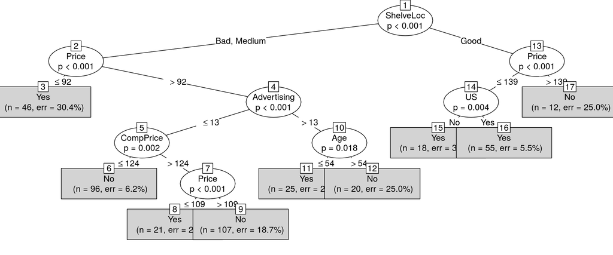

```r
plot(tree.carseats, type = "simple")
```

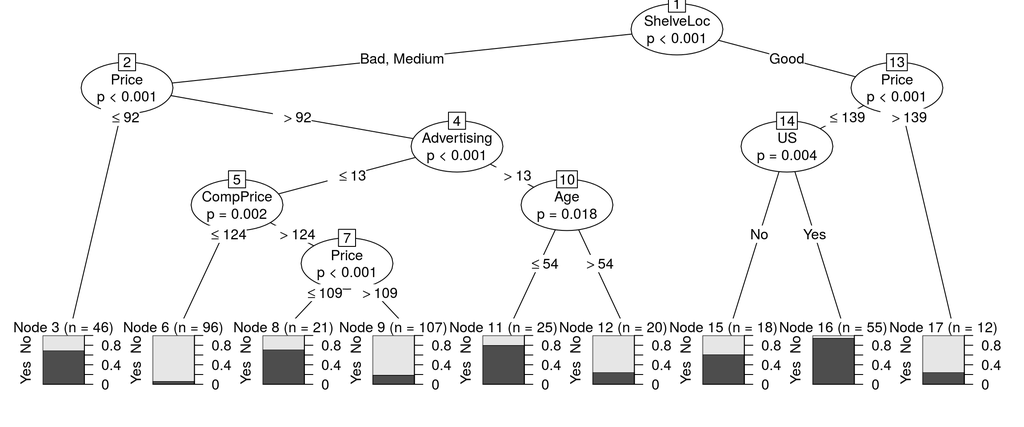

```r
plot(tree.carseats)
```

- Можете ли вы “прочитать” это дерево?
- Какие “правила” получились?
- Все ли переменные из данных использованы?

Но насколько хорошо такие правила описывают закономерности?

Разделим данные на две части: на одной будем строить модель, на другой – проверять.

- Почему бы не использовать полный датасет на всех этапах?

```r
set.seed(2)
train=sample(1:nrow(Carseats), 200)
Carseats.test <- Carseats[-train,]
Carseats.train <- Carseats[train,]
tree.carseats=ctree(High~.,Carseats.train)
```

Теперь предскажем значения (высокие продажи / низкие продажи) согласно этой модели и посмотрим, совпали ли наши предсказания с фактическими значениями

```r
tree.pred <- predict(tree.carseats, Carseats.test)
tree.pred
```

```
##   1   2   5   9  10  12  13  15  16  18  21  25  28  30  33  34  36  39
##  No Yes  No  No  No Yes  No Yes  No Yes  No  No  No  No Yes Yes  No  No
##  40  43  45  48  52  53  54  58  62  63  65  66  68  72  75  76  77  80
##  No Yes  No  No  No  No  No  No  No  No  No  No Yes Yes  No  No Yes  No
##  81  82  83  86  89  95  97  99 100 101 109 110 111 112 115 116 117 119
## Yes Yes Yes  No  No Yes Yes Yes  No  No  No  No  No  No  No  No  No  No
## 120 122 127 129 132 135 136 137 138 139 140 143 144 146 148 149 150 151
##  No  No Yes  No  No  No Yes  No  No  No  No  No  No  No Yes  No  No Yes
## 152 156 158 159 161 162 164 166 167 168 169 171 172 174 175 178 181 182
## Yes Yes  No Yes  No  No  No  No Yes  No  No  No Yes  No  No  No  No  No
## 183 185 186 188 190 191 193 194 195 196 197 198 199 200 201 205 206 207
##  No  No  No  No Yes  No  No Yes Yes  No  No  No  No  No  No  No  No  No
## 211 214 217 218 219 221 222 224 227 230 231 233 234 235 236 239 240 244
##  No  No  No  No  No Yes  No  No Yes Yes  No Yes Yes Yes  No Yes  No  No
## 245 249 250 251 255 256 257 260 261 263 264 267 268 272 274 276 277 278
##  No  No  No  No Yes Yes  No  No  No Yes  No Yes  No  No Yes  No Yes  No
## 279 282 287 288 290 291 292 294 295 297 298 300 304 307 309 310 311 312
##  No Yes  No Yes Yes Yes  No Yes Yes Yes  No Yes Yes  No Yes Yes Yes  No
## 313 314 316 320 321 324 326 330 331 332 333 335 336 338 342 343 344 348
##  No Yes  No Yes  No Yes  No Yes  No Yes Yes Yes Yes  No  No  No  No Yes
## 349 350 351 353 355 360 361 364 367 368 371 372 376 377 383 385 386 389
## Yes Yes Yes Yes  No  No Yes Yes  No Yes  No  No  No Yes Yes Yes  No Yes
## 394 395
##  No  No
## Levels: No Yes
```

```r
table(tree.pred, Carseats.test$High) ##confusion table
```

```
##
## tree.pred No Yes
##       No  97  30
##       Yes 19  54
```

```r
(97+54)/200
```

```
## [1] 0.755
```

### Построение регрессионных деревьев

Помяняем немного задачу: не будем делить на высокие и низкие продажи, а просто попробуем предсказать уровень продаж Sales

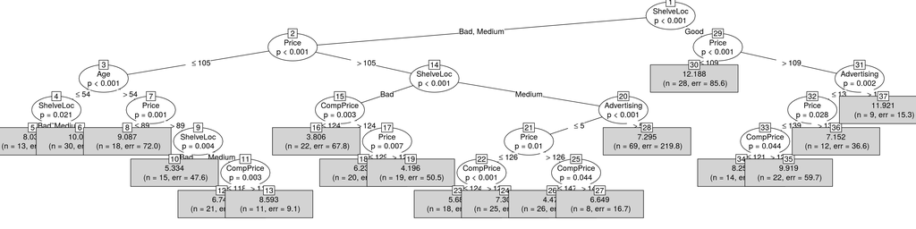

```r
carseats <- ISLR::Carseats
tree.regr <- ctree(Sales~., data = carseats)
plot(tree.regr, type = "simple")
```

```r
tree.regr
```

```
##
## Model formula:
## Sales ~ CompPrice + Income + Advertising + Population + Price +
##     ShelveLoc + Age + Education + Urban + US
##
## Fitted party:
## [1] root
## |   [2] ShelveLoc in Bad, Medium
## |   |   [3] Price <= 105
## |   |   |   [4] Age <= 54
## |   |   |   |   [5] ShelveLoc in Bad: 8.032 (n = 13, err = 27.5)
## |   |   |   |   [6] ShelveLoc in Medium: 10.011 (n = 30, err = 95.7)
## |   |   |   [7] Age > 54
## |   |   |   |   [8] Price <= 89: 9.087 (n = 18, err = 72.0)
## |   |   |   |   [9] Price > 89
## |   |   |   |   |   [10] ShelveLoc in Bad: 5.334 (n = 15, err = 47.6)
## |   |   |   |   |   [11] ShelveLoc in Medium
## |   |   |   |   |   |   [12] CompPrice <= 118: 6.744 (n = 21, err = 34.5)
## |   |   |   |   |   |   [13] CompPrice > 118: 8.593 (n = 11, err = 9.1)
## |   |   [14] Price > 105
## |   |   |   [15] ShelveLoc in Bad
## |   |   |   |   [16] CompPrice <= 124: 3.806 (n = 22, err = 67.8)
## |   |   |   |   [17] CompPrice > 124
## |   |   |   |   |   [18] Price <= 129: 6.230 (n = 20, err = 53.4)
## |   |   |   |   |   [19] Price > 129: 4.196 (n = 19, err = 50.5)
## |   |   |   [20] ShelveLoc in Medium
## |   |   |   |   [21] Advertising <= 5
## |   |   |   |   |   [22] Price <= 126
## |   |   |   |   |   |   [23] CompPrice <= 124: 5.684 (n = 18, err = 16.7)
## |   |   |   |   |   |   [24] CompPrice > 124: 7.305 (n = 25, err = 51.3)
## |   |   |   |   |   [25] Price > 126
## |   |   |   |   |   |   [26] CompPrice <= 147: 4.475 (n = 26, err = 87.9)
## |   |   |   |   |   |   [27] CompPrice > 147: 6.649 (n = 8, err = 16.7)
## |   |   |   |   [28] Advertising > 5: 7.295 (n = 69, err = 219.8)
## |   [29] ShelveLoc in Good
## |   |   [30] Price <= 109: 12.188 (n = 28, err = 85.6)
## |   |   [31] Price > 109
## |   |   |   [32] Advertising <= 13
## |   |   |   |   [33] Price <= 139
## |   |   |   |   |   [34] CompPrice <= 121: 8.256 (n = 14, err = 25.0)
## |   |   |   |   |   [35] CompPrice > 121: 9.919 (n = 22, err = 59.7)
## |   |   |   |   [36] Price > 139: 7.152 (n = 12, err = 36.6)
## |   |   |   [37] Advertising > 13: 11.921 (n = 9, err = 15.3)
##
## Number of inner nodes:    18
## Number of terminal nodes: 19
```

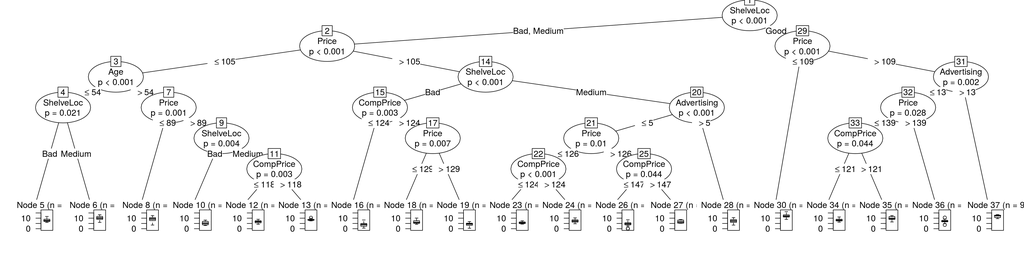

```r
plot(tree.regr)
```

- Какие “правила” для предсказания продаж мы получили в этом случае?

Как оценить качество регрессионной модели? Разделим выборку снова на две части

```r
set.seed(2)
train=sample(1:nrow(carseats), 200)
carseats.test <- carseats[-train,]
carseats.train <- carseats[train,]
tree.regr <- ctree(Sales~., carseats.train)
```

- что будет. если мы попробуем построить матрицу неcоответствий (confusion matrix)?

```r
tree.pred <- predict(tree.regr, carseats.test)
tree.pred
```

```
##         1         2         5         9        10        12        13
##  5.883103 12.539091  5.113214  6.585500  6.585500 10.055000  3.508182
##        15        16        18        21        25        28        30
## 10.055000  7.017273 10.055000  5.113214  5.883103  6.585500  5.883103
##        33        34        36        39        40        43        45
##  7.347500 10.055000  8.296364  6.585500  5.113214  9.833750  6.585500
##        48        52        53        54        58        62        63
##  5.883103  5.883103  7.017273  8.296364  5.883103  6.585500  5.113214
##        65        66        68        72        75        76        77
##  8.296364  3.508182  8.296364  7.017273  7.017273  5.883103  9.833750
##        80        81        82        83        86        89        95
##  5.883103  5.883103 10.055000  7.347500  6.585500  6.585500  5.883103
##        97        99       100       101       109       110       111
## 10.055000 10.055000  5.883103  8.296364  5.883103  9.833750  6.585500
##       112       115       116       117       119       120       122
##  5.113214  6.585500  5.113214  5.113214  6.585500  5.113214  5.883103
##       127       129       132       135       136       137       138
## 10.055000  5.113214  9.833750  5.113214  8.296364  5.883103  6.585500
##       139       140       143       144       146       148       149
##  8.296364  9.833750  6.585500  3.508182  9.397143 10.055000  6.585500
##       150       151       152       156       158       159       161
##  9.833750 10.055000 10.055000  9.833750  9.833750 10.055000  6.585500
##       162       164       166       167       168       169       171
##  5.113214  5.883103  7.017273  3.508182  9.833750  6.585500  8.296364
##       172       174       175       178       181       182       183
##  9.833750  5.113214  5.113214  9.833750  5.113214  9.833750  5.113214
##       185       186       188       190       191       193       194
##  6.585500  8.296364  5.883103  8.296364  8.296364  9.833750 10.055000
##       195       196       197       198       199       200       201
##  3.508182  5.883103  5.113214  5.113214  3.508182  3.508182  7.017273
##       205       206       207       211       214       217       218
##  9.397143  3.508182  7.017273  5.883103  7.017273  5.113214  6.585500
##       219       221       222       224       227       230       231
##  8.296364  8.296364  6.585500  6.585500 10.055000  9.833750  5.883103
##       233       234       235       236       239       240       244
## 10.055000  8.296364 10.055000  5.113214 10.055000  5.883103  8.296364
##       245       249       250       251       255       256       257
##  6.585500  6.585500  5.883103  7.347500 10.055000  5.883103  7.017273
##       260       261       263       264       267       268       272
##  5.883103  5.883103  3.508182  6.585500 10.055000  5.883103  6.585500
##       274       276       277       278       279       282       287
##  9.833750  3.508182  5.113214  8.296364  7.347500 10.055000  8.296364
##       288       290       291       292       294       295       297
##  5.883103  5.113214  8.296364  5.883103 12.539091 10.055000 10.055000
##       298       300       304       307       309       310       311
##  5.883103  8.296364  8.296364  5.113214  5.113214  5.883103  7.017273
##       312       313       314       316       320       321       324
##  7.017273  5.113214  9.833750  7.347500  5.113214  5.113214  8.296364
##       326       330       331       332       333       335       336
##  9.397143 12.539091  5.883103  5.113214  8.296364  5.883103  8.296364
##       338       342       343       344       348       349       350
##  6.585500  9.833750  8.296364  5.883103 10.055000 10.055000  8.296364
##       351       353       355       360       361       364       367
##  9.833750 10.055000  5.113214  5.113214 10.055000 10.055000  5.113214
##       368       371       372       376       377       383       385
## 12.539091  5.883103  7.017273  6.585500 10.055000  8.296364 10.055000
##       386       389       394       395
##  5.113214  5.883103  8.296364  5.113214
```

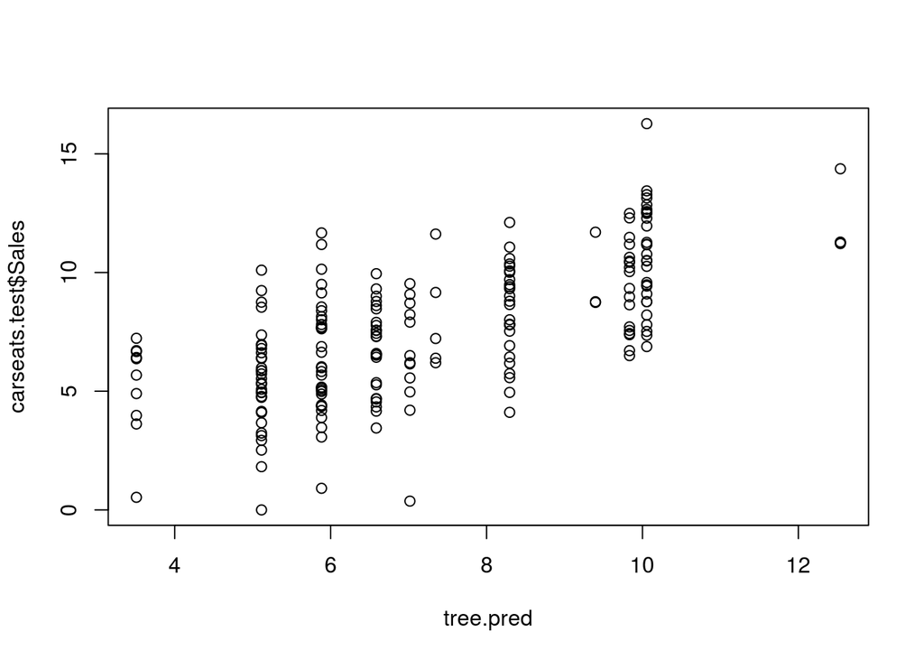

```r
plot(tree.pred, carseats.test$Sales)
```

Посчитаем, насколько наше предсказание отличается от реального значения

```r
mean((tree.pred - carseats.test$Sales)^2)
```

```
## [1] 4.654401
```

**Ваша очередь:**

Загрузите данные о стоимости квартир в пригородах Бостона (Boston). Более подробная информация в справке `?Boston`

```r
library(MASS)
data(Boston)
```

Разделите цену на высокую и низкую (граница 20)

```r
High=ifelse(Boston$medv<=20,"No","Yes")
Boston <- data.frame(Boston, High)
Boston <- dplyr::select(Boston, -medv)
```

Постройте модели для предсказания цены на квартиры * высокая/низкая * конкретное значение